# Tutorial-For-H20

Thomas Johnson III

9/21/2021

# Setup

Installing the package:

```r
#install.packages(h2o)
#install.packages(tidyverse)
#install.packages(dslabs)
```

Link to Java SE supported package: https://www.oracle.com/java/technologies/javase/jdk15-archive-downloads.html

Loading necessary libraries:

```r
library(h2o)
library(dslabs)
library(tidyverse)
```

Initializing an h2o cluster:

```r
set.seed(10)
h2o.init(max_mem_size = "3G") #Please alter the value of max_mem_size based on the amount of memory your system can provide or that you can allocate to the H2O cluster. Currently set at 3GB of memory.
# If the h2o cluster is not initialized, an error asking for the h2o cluster to be initialized will occur.
```

```r
data(brca) #Getting the first dataset
head(data.frame(brca))
brca_frame <- as.h2o(data.frame(brca))
```

## How to Split Datasets

```r
brca_splits <- h2o.splitFrame(brca_frame, ratios = 0.7) #Splitting into train
# and test datasets.
brca_training_set <- brca_splits[[1]] #Training dataset created
brca_testing_set <- brca_splits[[2]] #Testing dataset created
```

As a precaution, h2o can take up significant resources. If your computer slows down while the code is running that is to be expected. `max_runtime_secs = 30` sets the max time that h2o can use to build models to be no more than 30 seconds.

## Using h2o.automl()

```r
y_brca_data_label <- "y" # Name of the labels that the models will be training classify with
aml_of_brca <- h2o.automl(y = y_brca_data_label, training_frame = brca_training_set, max_runtime_secs = 30, nfolds = 3,  project_name = "automated_ML_first_run", seed =10) # Building a set of machine learning models from the data. Using 3 fold cross validation.
#can also use max_models top construct a specific number of models.
lb_of_brca <- h2o.get_leaderboard(aml_of_brca) # Getting the leaderboard of the models that were generated.
```

The models that were generated can now be viewed with next cell.

```r
head(lb_of_brca)
```

```
##                                                 model_id       auc    logloss
## 1    StackedEnsemble_AllModels_1_AutoML_1_20220115_31937 0.9982901 0.05121596
## 2    DeepLearning_grid_1_AutoML_1_20220115_31937_model_2 0.9982087 0.06514017
## 3 StackedEnsemble_BestOfFamily_2_AutoML_1_20220115_31937 0.9981001 0.05381685
## 4                          GBM_4_AutoML_1_20220115_31937 0.9980458 0.05748751
## 5 StackedEnsemble_BestOfFamily_3_AutoML_1_20220115_31937 0.9980458 0.05232769
## 6                          GLM_1_AutoML_1_20220115_31937 0.9980458 0.06812057
##       aucpr mean_per_class_error      rmse        mse
## 1 0.9974218           0.02191673 0.1245044 0.01550136
## 2 0.9973768           0.01481924 0.1210044 0.01464207
## 3 0.9971553           0.02191673 0.1271905 0.01617743
## 4 0.9969561           0.03058843 0.1366525 0.01867391
## 5 0.9971514           0.01986755 0.1217559 0.01482449
## 6 0.9972140           0.01529421 0.1330745 0.01770884
```

```r
dim(lb_of_brca)
```

```
## [1] 181   7
```

If we increase the time, more models can be generated as a result:

```r
aml_of_brca_set_2 <- h2o.automl(y = y_brca_data_label, training_frame = brca_testing_set, max_runtime_secs = 60, nfolds = 3, project_name = "automated_ML_second_run", seed = 10) # Building a set of machine learning models from the data. Using 3 fold cross validation.
lb_of_brca_set_2 <- h2o.get_leaderboard(aml_of_brca_set_2) # Getting the leaderboard of the models that were generated.
```

```r
head(lb_of_brca_set_2)
```

```
##                                               model_id       auc   logloss
## 1 DeepLearning_grid_7_AutoML_11_20220115_34503_model_5 0.9932157 0.2099814
## 2          GBM_grid_2_AutoML_5_20220115_32825_model_33 0.9911805 0.1193726
## 3  DeepLearning_grid_6_AutoML_8_20220115_33219_model_5 0.9909091 0.2085784
## 4          GBM_grid_6_AutoML_17_20220115_40212_model_9 0.9909091 0.1203774
## 5           GBM_grid_3_AutoML_8_20220115_33219_model_9 0.9909091 0.1203774
## 6           GBM_grid_2_AutoML_5_20220115_32825_model_9 0.9909091 0.1203774
##       aucpr mean_per_class_error      rmse        mse
## 1 0.9906054           0.04185889 0.1887331 0.03562020
## 2 0.9872171           0.03310719 0.1870560 0.03498994
## 3 0.9884037           0.03894166 0.1774760 0.03149773
## 4 0.9866850           0.03602442 0.1842602 0.03395182
## 5 0.9866850           0.03602442 0.1842602 0.03395182
## 6 0.9866850           0.03602442 0.1842602 0.03395182
```

```r
dim(lb_of_brca_set_2)
```

```
## [1] 479   7
```

## Information on Some of the Metrics

Reference: https://docs.h2o.ai/h2o/latest-stable/h2o-docs/performance-and-prediction.html?highlight=AUC#auc-area-under-the-roc-curve, Copyright 2016-2021 H2O.ai. Last updated on Sep 14, 2021

(The following information is from the source above)

The Area Under the ROC Curve (auc) is used as a metric to evaluate the performance of a classification. Should be used with caution as it only considers the true positives and false positives.

Area Under the Precision-Recall Curve is another metric to evaluate performance. True positives, false positives and false negatives are taken into consideration, but not true negatives. Considered much more reliable than AUC when handling a dataset that lacks equilibrium in the data.

Additionally, more metrics can be found within the H2O documentation.

## Accessing the Models From the AutoML Object

```r
#Get the model with the best performance as displayed in the leaderboard
best_model <- h2o.get_best_model(aml_of_brca)
print(best_model) #Prints multiple dataframes on the performance metrics and structure of that particular model
```

```
## Model Details:
## ==============
##
## H2OBinomialModel: stackedensemble
## Model ID:  StackedEnsemble_AllModels_1_AutoML_1_20220115_31937
## Number of Base Models: 8
##
## Base Models (count by algorithm type):
##
##     drf     gbm     glm xgboost
##       1       4       1       2
##
## Metalearner:
##
## Metalearner algorithm: glm
## Metalearner cross-validation fold assignment:
##   Fold assignment scheme: AUTO
##   Number of folds: 3
##   Fold column: NULL
## Metalearner hyperparameters:
##
##
## H2OBinomialMetrics: stackedensemble
## ** Reported on training data. **
##
## MSE:  0.0002782967
## RMSE:  0.01668223
## LogLoss:  0.004317423
## Mean Per-Class Error:  0
## AUC:  1
## AUCPR:  1
## Gini:  1
##
## Confusion Matrix (vertical: actual; across: predicted) for F1-optimal threshold:
##          B   M    Error    Rate
## B      244   0 0.000000  =0/244
## M        0 151 0.000000  =0/151
## Totals 244 151 0.000000  =0/395
##
## Maximum Metrics: Maximum metrics at their respective thresholds
```

[output cut: 47 more lines]

```
## 6                   max recall  0.061517   1.000000 159
## 7              max specificity  1.000000   1.000000   0
## 8             max absolute_mcc  0.652183   0.962589 135
## 9   max min_per_class_accuracy  0.425956   0.973510 140
## 10 max mean_per_class_accuracy  0.425956   0.978558 140
## 11                     max tns  1.000000 244.000000   0
## 12                     max fns  1.000000 148.000000   0
## 13                     max fps  0.000001 244.000000 384
## 14                     max tps  0.061517 151.000000 159
## 15                     max tnr  1.000000   1.000000   0
## 16                     max fnr  1.000000   0.980132   0
## 17                     max fpr  0.000001   1.000000 384
## 18                     max tpr  0.061517   1.000000 159
##
## Gains/Lift Table: Extract with `h2o.gainsLift(<model>, <data>)` or `h2o.gainsLift(<model>, valid=<T/F>, xval=<T/F>)`
```

```r
#Grabbing a model based on the model's ID
#different_model_by_ID <- h2o.getModel("GLM_1_AutoML_20210928_120820")#Type in a model ID in the parentheses from the automl output
#print(different_model_by_ID)
```

## Predictions of a Model

Building a random forest with 75 trees:

```r
brca_rand_forest.trees_75 <- h2o.randomForest(training_frame = brca_training_set, y = y_brca_data_label, ntrees = 75, nfolds = 3, seed=10, keep_cross_validation_predictions = TRUE)
```

Now predicting on the test dataset:

```r
pred_of_rand_forest <- h2o.predict(brca_rand_forest.trees_75, newdata = brca_testing_set) #Using the test set from splitting the brca frame earlier
brca_rand_forest.trees_75
```

```
## Model Details:
## ==============
##
## H2OBinomialModel: drf
## Model ID:  DRF_model_R_1642234774330_52267
## Model Summary:
##   number_of_trees number_of_internal_trees model_size_in_bytes min_depth
## 1              75                       75               19790         4
##   max_depth mean_depth min_leaves max_leaves mean_leaves
## 1         9    6.57333          9         23    16.37333
##
##
## H2OBinomialMetrics: drf
## ** Reported on training data. **
## ** Metrics reported on Out-Of-Bag training samples **
##
## MSE:  0.03034329
## RMSE:  0.1741933
## LogLoss:  0.1902095
## Mean Per-Class Error:  0.03425939
## AUC:  0.9898646
## AUCPR:  0.9868279
## Gini:  0.9797292
## R^2:  0.8698123
##
## Confusion Matrix (vertical: actual; across: predicted) for F1-optimal threshold:
##          B   M    Error     Rate
## B      242   5 0.020243   =5/247
## M        7 138 0.048276   =7/145
## Totals 249 143 0.030612  =12/392
##
## Maximum Metrics: Maximum metrics at their respective thresholds
##                         metric threshold      value idx
## 1                       max f1  0.551724   0.958333  49
## 2                       max f2  0.346154   0.963115  58
## 3                 max f0point5  0.769231   0.964778  37
## 4                 max accuracy  0.551724   0.969388  49
## 5                max precision  1.000000   1.000000   0
## 6                   max recall  0.000000   1.000000 120
## 7              max specificity  1.000000   1.000000   0
```

[output cut: 62 more lines]

```
## f1                      0.955461 0.012866   0.970297   0.947368   0.948718
## f2                      0.960753 0.013985   0.976096   0.957447   0.948718
## lift_top_group          2.743712 0.339116   2.700000   2.428571   3.102564
## logloss                 0.132860 0.051837   0.095562   0.192052   0.110966
## max_per_class_error     0.041604 0.015666   0.023529   0.050000   0.051282
## mcc                     0.928941 0.021789   0.952668   0.909829   0.924328
## mean_per_class_accuracy 0.965847 0.011018   0.978235   0.957143   0.962164
## mean_per_class_error    0.034153 0.011018   0.021765   0.042857   0.037836
## mse                     0.033159 0.008557   0.026256   0.042733   0.030490
## pr_auc                  0.986956 0.006151   0.993486   0.981272   0.986112
## precision               0.946846 0.014963   0.960784   0.931034   0.948718
## r2                      0.857132 0.032043   0.887409   0.823575   0.860413
## recall                  0.964335 0.015641   0.980000   0.964286   0.948718
## rmse                    0.181123 0.023042   0.162036   0.206719   0.174613
## specificity             0.967360 0.015040   0.976471   0.950000   0.975610
```

```r
print(pred_of_rand_forest)
```

```
##   predict         B         M
## 1       B 1.0000000 0.0000000
## 2       B 1.0000000 0.0000000
## 3       B 1.0000000 0.0000000
## 4       B 1.0000000 0.0000000
## 5       B 1.0000000 0.0000000
## 6       B 0.4933333 0.5066667
##
## [177 rows x 3 columns]
```

## Building Specific Models

We can also build specific models based on the options provided. Support for particular models such as XGBoost will differ by operating system. We will start with the GLM Model:

Reference:https://docs.h2o.ai/h2o/latest-stable/h2o-docs/data-science/glm.html

```r
#Generates the GLM model
first_glm <- h2o.glm(model_id ="First_GLM",y = y_brca_data_label, training_frame = brca_training_set, nfolds = 3, seed =10, keep_cross_validation_predictions = TRUE)
first_glm
```

```
## Model Details:
## ==============
##
## H2OBinomialModel: glm
## Model ID:  First_GLM
## GLM Model: summary
##     family  link                               regularization
## 1 binomial logit Elastic Net (alpha = 0.5, lambda = 0.07633 )
##   number_of_predictors_total number_of_active_predictors number_of_iterations
## 1                         30                          15                    5
##    training_frame
## 1 RTMP_sid_81da_3
##
## Coefficients: glm coefficients
##              names coefficients standardized_coefficients
## 1        Intercept    -9.886067                 -0.665962
## 2    x.radius_mean     0.054363                  0.194915
## 3   x.texture_mean     0.028412                  0.118503
## 4 x.perimeter_mean     0.008010                  0.197703
## 5      x.area_mean     0.000285                  0.103650
##
## ---
##                  names coefficients standardized_coefficients
## 26  x.smoothness_worst     4.797207                  0.109246
## 27 x.compactness_worst     0.000000                  0.000000
## 28   x.concavity_worst     0.505077                  0.105500
## 29 x.concave_pts_worst     7.124482                  0.467117
## 30    x.symmetry_worst     3.158817                  0.197889
## 31 x.fractal_dim_worst     0.000000                  0.000000
##
## H2OBinomialMetrics: glm
## ** Reported on training data. **
##
## MSE:  0.04208126
## RMSE:  0.2051372
## LogLoss:  0.1756046
## Mean Per-Class Error:  0.02676253
## AUC:  0.9966494
## AUCPR:  0.9949638
## Gini:  0.9932989
```

[output cut: 77 more lines]

```
##               mean       sd cv_1_valid cv_2_valid cv_3_valid
## accuracy  0.967189 0.023074   0.985185   0.941176   0.975207
## auc       0.993054 0.005590   0.997647   0.986830   0.994684
## err       0.032811 0.023074   0.014815   0.058824   0.024793
## err_count 4.333334 3.214550   2.000000   8.000000   3.000000
## f0point5  0.948979 0.034288   0.980000   0.912162   0.954774
##
## ---
##                        mean       sd cv_1_valid cv_2_valid cv_3_valid
## precision          0.943333 0.040415   0.980000   0.900000   0.950000
## r2                 0.755594 0.037060   0.775917   0.712819   0.778046
## recall             0.972882 0.007961   0.980000   0.964286   0.974359
## residual_deviance 58.750053 9.461277  58.917995  68.126240  49.205925
## rmse               0.237506 0.023106   0.228594   0.263741   0.220184
## specificity        0.962948 0.033465   0.988235   0.925000   0.975610
```

The h2o.explain() function allows for further insight for the model’s predictions on the testing set. This includes a chart on relative variable importance.

```r
h2o.explain(first_glm, newdata =brca_testing_set)
```

```
##
##
## Confusion Matrix
## ================
##
## > Confusion matrix shows a predicted class vs an actual class.
##
##
##
## First_GLM
## ---------
##
## |  | B | M | Error | Rate
## |:---:|:---:|:---:|:---:|:---:|
## | **B** |110 | 0 | 0 | 1 |
## | **M** |4 | 63 | 0.05970149 | 3 |
## | **Totals** |114 | 63 | 0.02259887 | 2 |
##
##
## Variable Importance
## ===================
##
## > The variable importance plot shows the relative importance of the most important variables in the model.
```

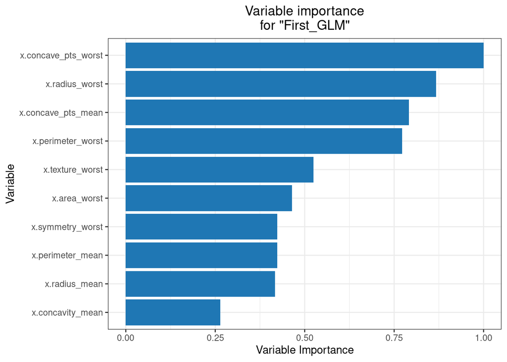

```
##
##
## Partial Dependence Plots
## ========================
##
## > Partial dependence plot (PDP) gives a graphical depiction of the marginal effect of a variable on the response. The effect of a variable is measured in change in the mean response. PDP assumes independence between the feature for which is the PDP computed and the rest.
```

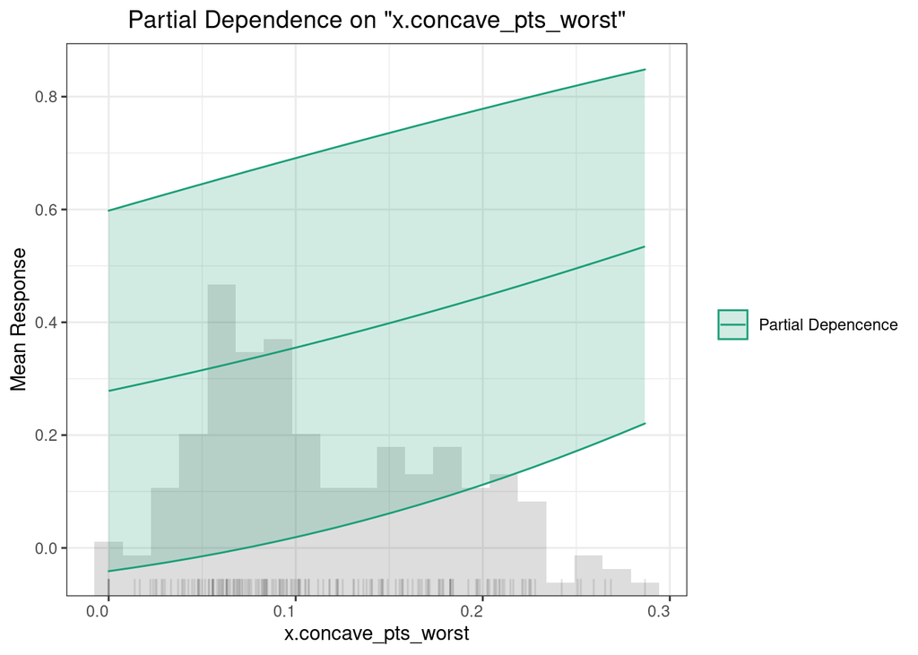

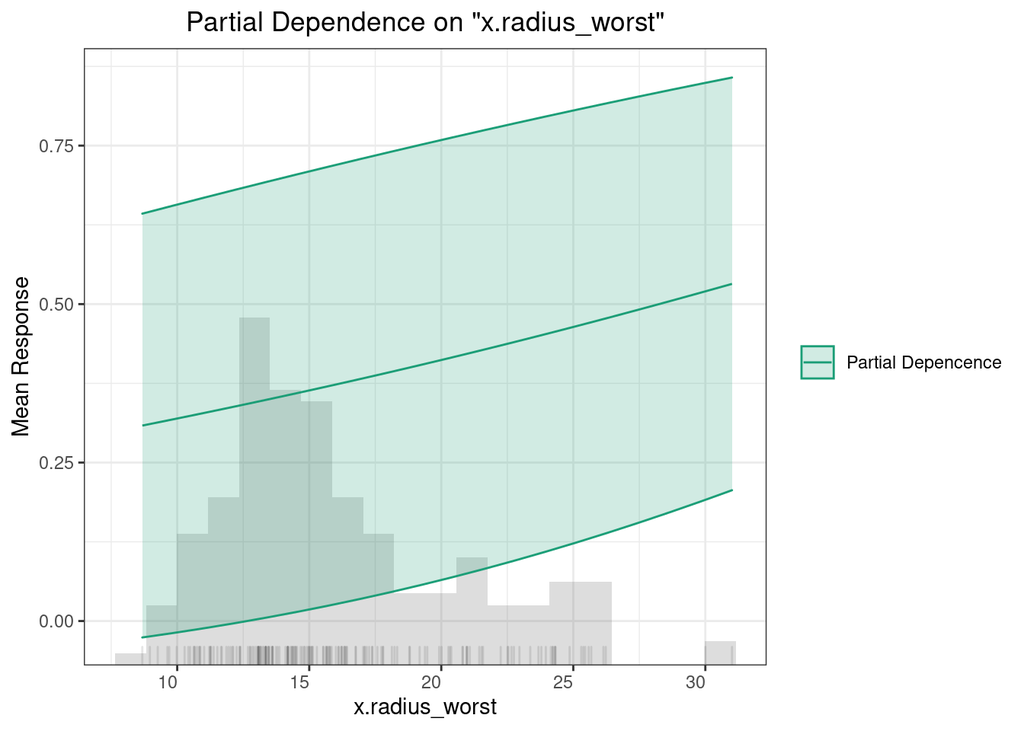

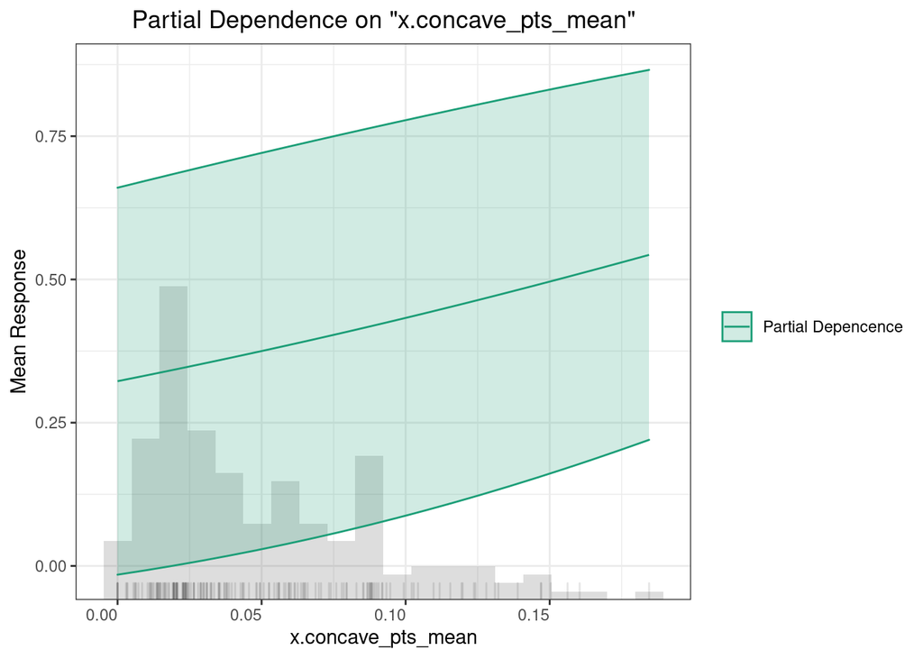

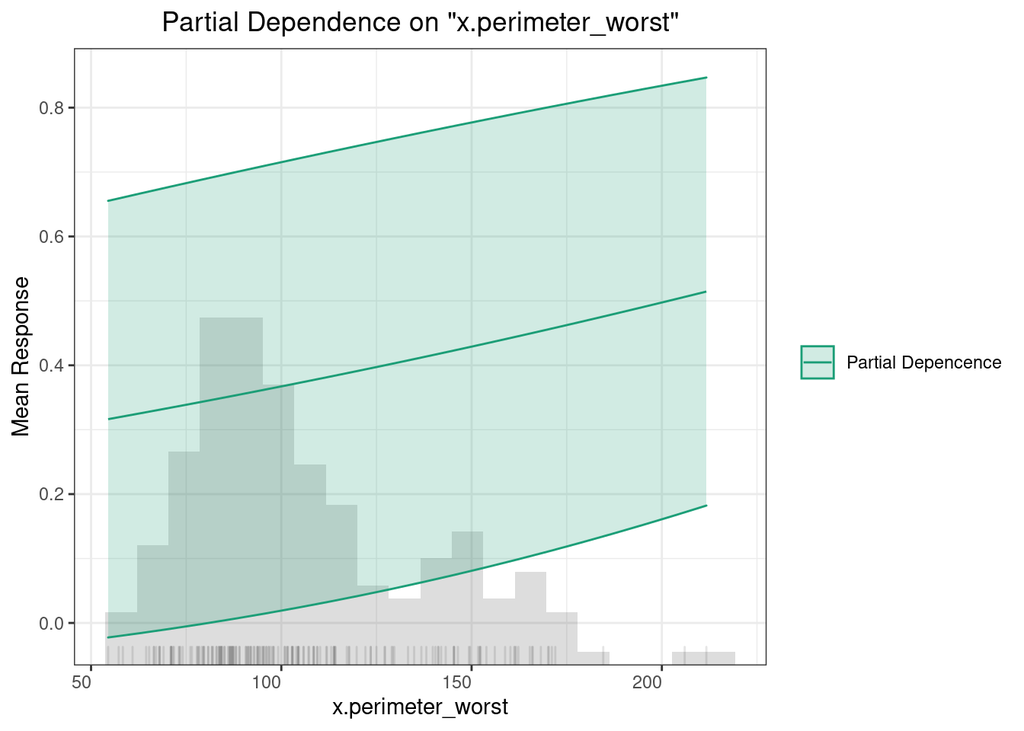

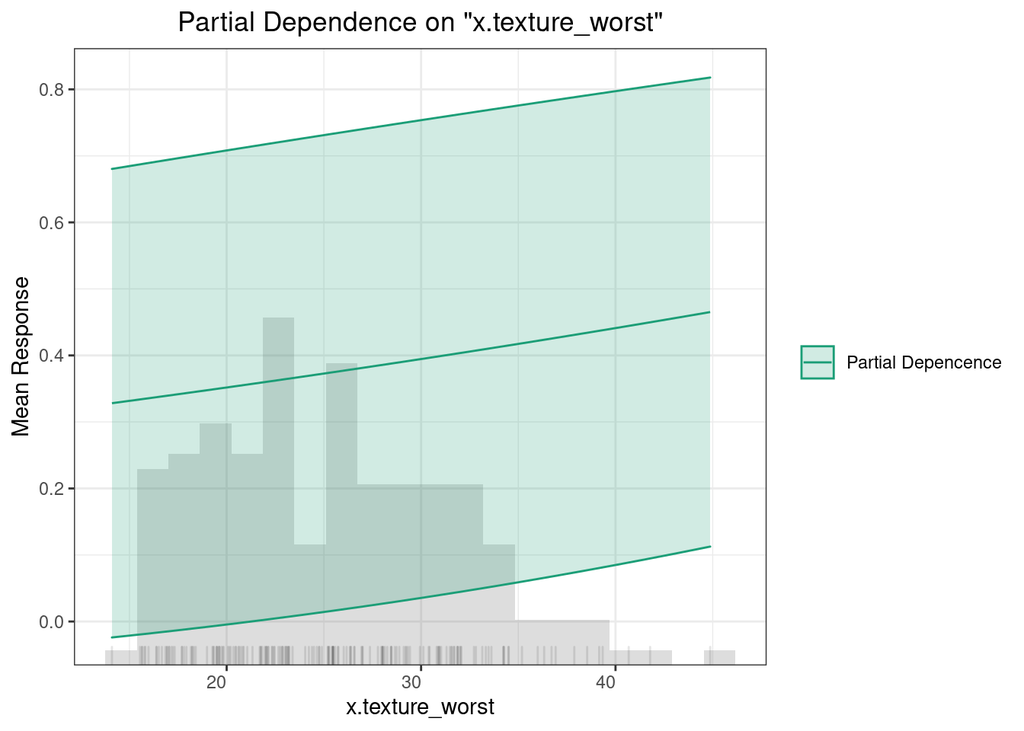

Next is a deep learning model: Reference: https://docs.h2o.ai/h2o/latest-stable/h2o-docs/data-science/deep-learning.html

```r
first_deep_learn.mod <- h2o.deeplearning(y = y_brca_data_label, training_frame = brca_training_set, model_id = "brca_deep_learn_mod_1", nfolds = 3, epochs = 11, seed =10, keep_cross_validation_predictions = TRUE) #Building a deep learning bodel for classifying BRCA data
first_deep_learn.mod
```

```
## Model Details:
## ==============
##
## H2OBinomialModel: deeplearning
## Model ID:  brca_deep_learn_mod_1
## Status of Neuron Layers: predicting y, 2-class classification, bernoulli distribution, CrossEntropy loss, 46,802 weights/biases, 560.5 KB, 4,473 training samples, mini-batch size 1
##   layer units      type dropout       l1       l2 mean_rate rate_rms momentum
## 1     1    30     Input  0.00 %       NA       NA        NA       NA       NA
## 2     2   200 Rectifier  0.00 % 0.000000 0.000000  0.006087 0.006175 0.000000
## 3     3   200 Rectifier  0.00 % 0.000000 0.000000  0.023541 0.084971 0.000000
## 4     4     2   Softmax      NA 0.000000 0.000000  0.002120 0.003007 0.000000
##   mean_weight weight_rms mean_bias bias_rms
## 1          NA         NA        NA       NA
## 2    0.001599   0.095948  0.488131 0.012251
## 3   -0.001045   0.069994  0.997694 0.005713
## 4   -0.032888   0.406553 -0.001161 0.000465
##
##
## H2OBinomialMetrics: deeplearning
## ** Reported on training data. **
## ** Metrics reported on full training frame **
##
## MSE:  0.01336757
## RMSE:  0.1156182
## LogLoss:  0.03958212
## Mean Per-Class Error:  0.006896552
## AUC:  0.9995533
## AUCPR:  0.9992799
## Gini:  0.9991065
##
## Confusion Matrix (vertical: actual; across: predicted) for F1-optimal threshold:
##          B   M    Error    Rate
## B      247   0 0.000000  =0/247
## M        2 143 0.013793  =2/145
## Totals 249 143 0.005102  =2/392
##
## Maximum Metrics: Maximum metrics at their respective thresholds
##                         metric threshold      value idx
## 1                       max f1  0.969941   0.993056  28
## 2                       max f2  0.969941   0.988935  28
```

[output cut: 66 more lines]

```
## f1                      0.974704 0.014607   0.990099   0.972973   0.961039
## f2                      0.972455 0.021593   0.996016   0.967742   0.953608
## lift_top_group          2.743712 0.339116   2.700000   2.428571   3.102564
## logloss                 0.106167 0.067838   0.030612   0.161850   0.126038
## max_per_class_error     0.032920 0.019906   0.011765   0.035714   0.051282
## mcc                     0.960597 0.021312   0.984306   0.954453   0.943033
## mean_per_class_accuracy 0.979424 0.013285   0.994118   0.975893   0.968261
## mean_per_class_error    0.020576 0.013285   0.005882   0.024107   0.031739
## mse                     0.020930 0.009276   0.010393   0.027865   0.024532
## pr_auc                  0.995307 0.003861   0.999604   0.994188   0.992130
## precision               0.978631 0.004343   0.980392   0.981818   0.973684
## r2                      0.909360 0.039925   0.955434   0.884957   0.887689
## recall                  0.971001 0.026292   1.000000   0.964286   0.948718
## rmse                    0.141833 0.034927   0.101944   0.166928   0.156627
## specificity             0.987847 0.000369   0.988235   0.987500   0.987805
```

```r
h2o.explain(first_deep_learn.mod, newdata =brca_testing_set)
```

```
##
##
## Confusion Matrix
## ================
##
## > Confusion matrix shows a predicted class vs an actual class.
##
##
##
## brca_deep_learn_mod_1
## ---------------------
##
## |  | B | M | Error | Rate
## |:---:|:---:|:---:|:---:|:---:|
## | **B** |108 | 2 | 0.01818182 | 1 |
## | **M** |2 | 65 | 0.02985075 | 2 |
## | **Totals** |110 | 67 | 0.02259887 | 3 |
##
##
## Variable Importance
## ===================
##
## > The variable importance plot shows the relative importance of the most important variables in the model.
```

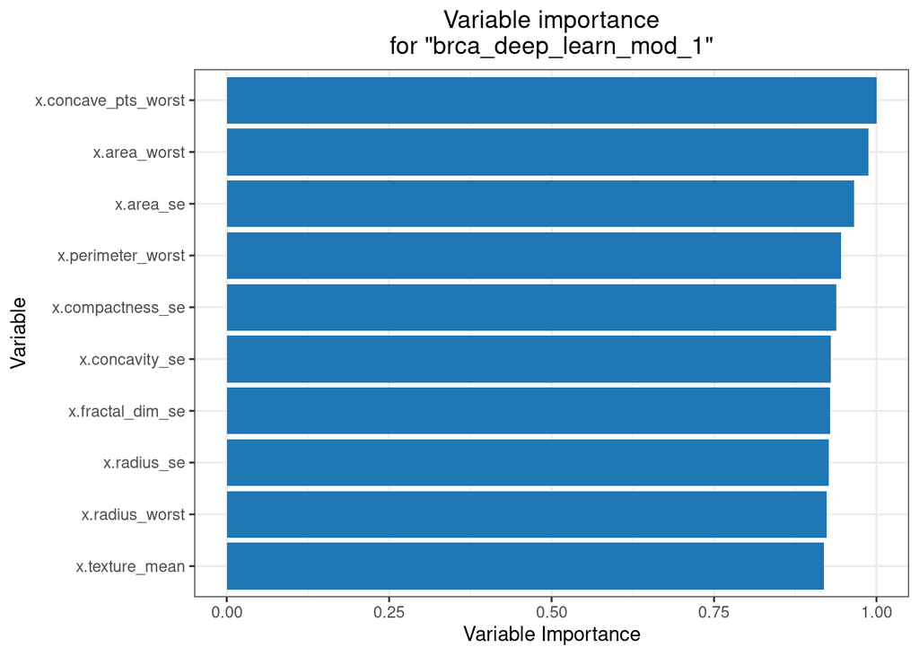

```
##
##
## Partial Dependence Plots
## ========================
##
## > Partial dependence plot (PDP) gives a graphical depiction of the marginal effect of a variable on the response. The effect of a variable is measured in change in the mean response. PDP assumes independence between the feature for which is the PDP computed and the rest.
```

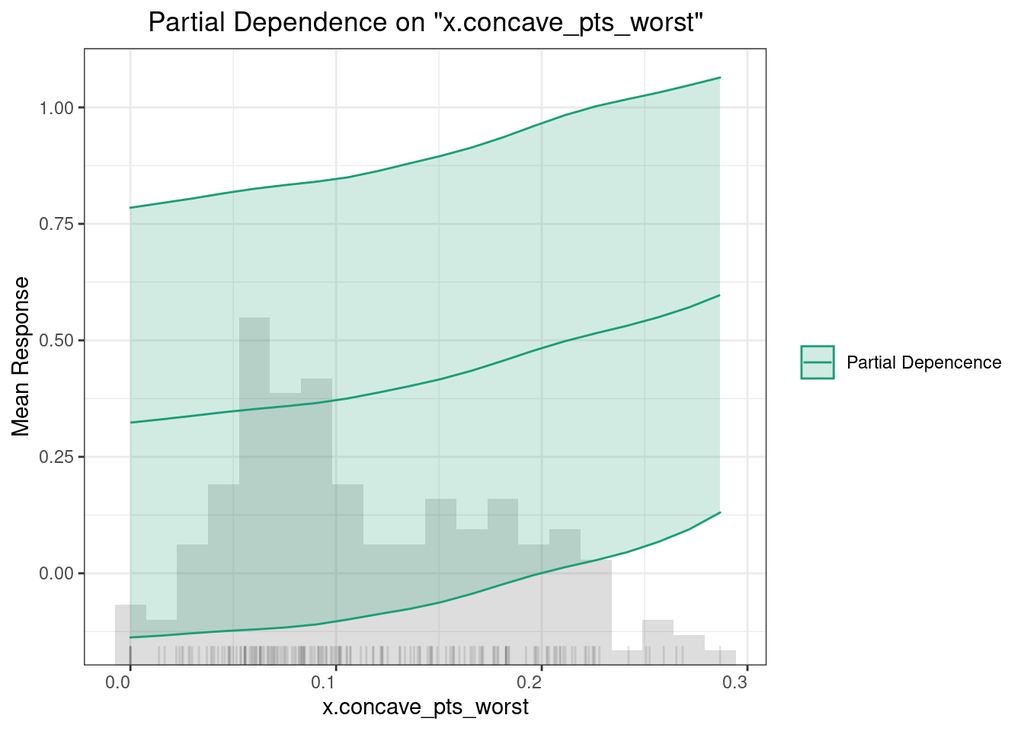

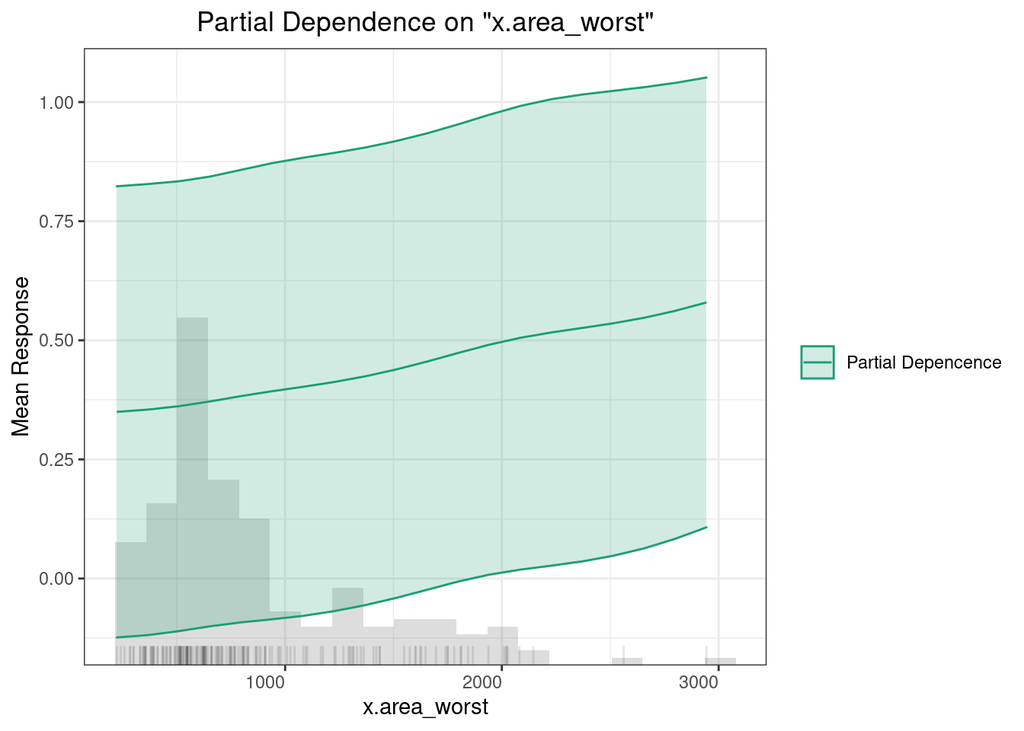

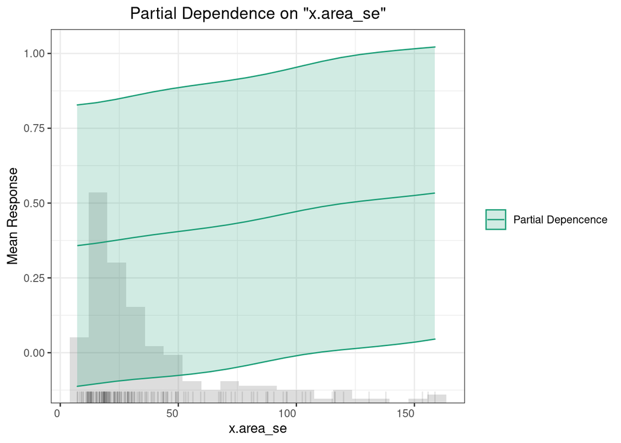

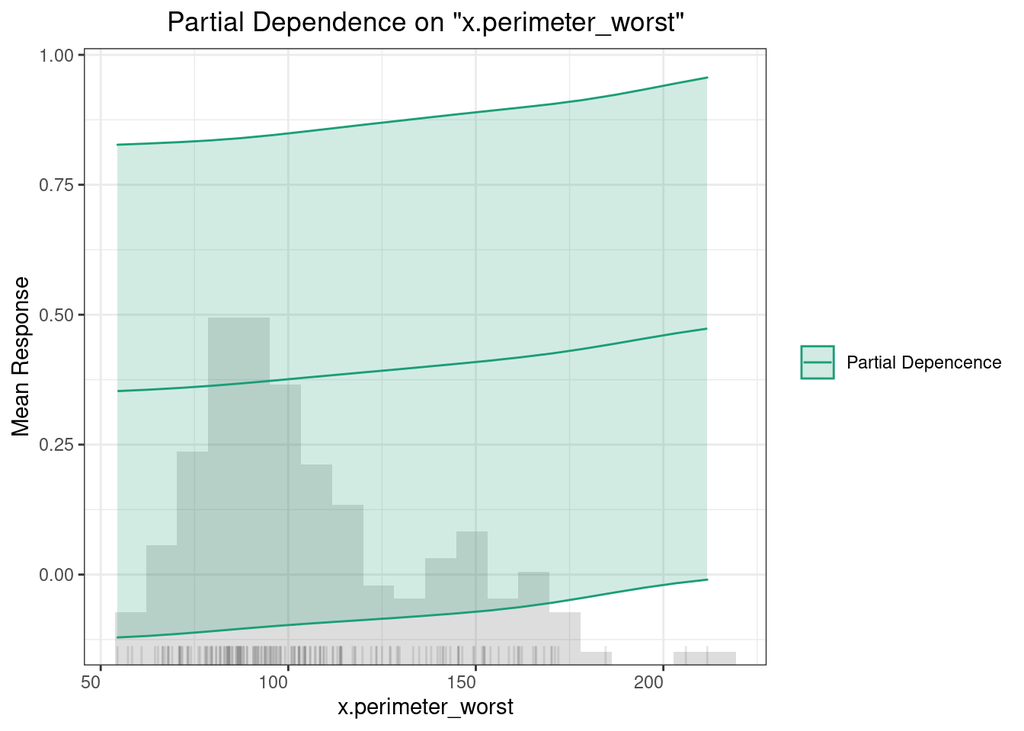

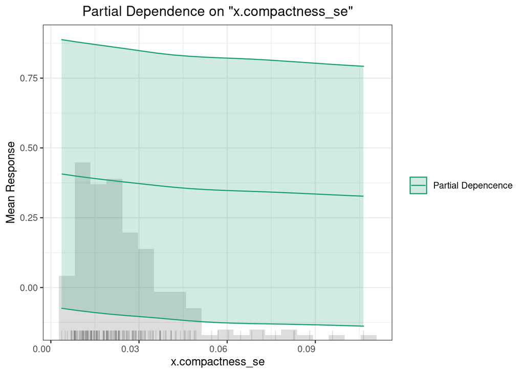

```r
first_ensemble_brca <- h2o.stackedEnsemble(y = y_brca_data_label, training_frame = brca_training_set,model_id = "brca_st_ensemble_mod_1", metalearner_nfolds =3, base_models = list(first_deep_learn.mod, first_glm,brca_rand_forest.trees_75)) #A list of specified models to used for the stacked ensemble is required.
first_ensemble_brca #Note that the ensemble depends heavily on the base models to be able to achieve high performacne.
```

```
## Model Details:
## ==============
##
## H2OBinomialModel: stackedensemble
## Model ID:  brca_st_ensemble_mod_1
## Number of Base Models: 3
##
## Base Models (count by algorithm type):
##
## deeplearning          drf          glm
##            1            1            1
##
## Metalearner:
##
## Metalearner algorithm: glm
## Metalearner cross-validation fold assignment:
##   Fold assignment scheme: AUTO
##   Number of folds: 3
##   Fold column: NULL
## Metalearner hyperparameters:
##
##
## H2OBinomialMetrics: stackedensemble
## ** Reported on training data. **
##
## MSE:  0.004163074
## RMSE:  0.06452189
## LogLoss:  0.02138984
## Mean Per-Class Error:  0.006896552
## AUC:  0.9998604
## AUCPR:  0.9997649
## Gini:  0.9997208
##
## Confusion Matrix (vertical: actual; across: predicted) for F1-optimal threshold:
##          B   M    Error    Rate
## B      247   0 0.000000  =0/247
## M        2 143 0.013793  =2/145
## Totals 249 143 0.005102  =2/392
##
## Maximum Metrics: Maximum metrics at their respective thresholds
```

[output cut: 47 more lines]

```
## 6                   max recall  0.003540   1.000000 346
## 7              max specificity  0.997509   1.000000   0
## 8             max absolute_mcc  0.458203   0.956219 144
## 9   max min_per_class_accuracy  0.458203   0.972414 144
## 10 max mean_per_class_accuracy  0.458203   0.978110 144
## 11                     max tns  0.997509 247.000000   0
## 12                     max fns  0.997509 144.000000   0
## 13                     max fps  0.002231 247.000000 391
## 14                     max tps  0.003540 145.000000 346
## 15                     max tnr  0.997509   1.000000   0
## 16                     max fnr  0.997509   0.993103   0
## 17                     max fpr  0.002231   1.000000 391
## 18                     max tpr  0.003540   1.000000 346
##
## Gains/Lift Table: Extract with `h2o.gainsLift(<model>, <data>)` or `h2o.gainsLift(<model>, valid=<T/F>, xval=<T/F>)`
```

## Regression

Time for some regression with the diamonds dataset, also have to slice the dataset for memory reasons:

```r
data(diamonds)# Loading the diamonds data
class(diamonds)
```

```
## [1] "tbl_df"     "tbl"        "data.frame"
```

```r
diamonds_fame_reduced <- slice_sample(diamonds, n =25000)
diamonds_fame_reduced$cut<- as.factor(as.character(diamonds_fame_reduced$cut))
diamonds_fame_reduced$color <- as.factor(as.character(diamonds_fame_reduced$color))
diamonds_fame_reduced$clarity <- as.factor(as.character(diamonds_fame_reduced$clarity))
head(diamonds_fame_reduced)
```

```
## # A tibble: 6 × 10
##   carat cut       color clarity depth table price     x     y     z
##   <dbl> <fct>     <fct> <fct>   <dbl> <dbl> <int> <dbl> <dbl> <dbl>
## 1  0.3  Very Good E     VS2      62.4    57   658  4.24  4.29  2.66
## 2  0.91 Ideal     J     VS1      61.9    56  3863  6.19  6.22  3.85
## 3  1.05 Very Good F     VS1      60.2    58  7276  6.62  6.74  4.02
## 4  0.43 Premium   D     VS2      60.7    58  1129  4.88  4.84  2.95
## 5  0.52 Ideal     G     SI1      62.6    56  1338  5.16  5.13  3.22
## 6  1.18 Ideal     E     I1       61.6    56  4229  6.82  6.79  4.19
```

```r
diamonds_frame <- as.h2o(data.frame(diamonds_fame_reduced)) #Converting to h2o frame
diamonds_split <- h2o.splitFrame(diamonds_frame, ratios = .75)# Splitting the data
#Now we get the train and test frames:
diamonds_train <- diamonds_split[[1]]
diamonds_test <- diamonds_split[[2]]
diamonds_label <- "price"
```

```r
diamonds_automl_collection_1 <- h2o.automl(y = diamonds_label, training_frame = diamonds_train, max_runtime_secs = 45, nfolds = 5, seed = 10) #Running automl for 45 seconds with 5-fold cross validation for diamonds data
```

[output not shown]

[output cut: 94 more lines]

[output not shown]

```r
diamonds_automl_collection.leaderboard<- h2o.get_leaderboard(diamonds_automl_collection_1)
print(diamonds_automl_collection.leaderboard)
```

```
##                                                  model_id
## 1    StackedEnsemble_AllModels_2_AutoML_18_20220115_40421
## 2 StackedEnsemble_BestOfFamily_3_AutoML_18_20220115_40421
## 3                          GBM_5_AutoML_18_20220115_40421
## 4    StackedEnsemble_AllModels_1_AutoML_18_20220115_40421
## 5 StackedEnsemble_BestOfFamily_2_AutoML_18_20220115_40421
## 6                          GBM_3_AutoML_18_20220115_40421
##   mean_residual_deviance     rmse      mse      mae     rmsle
## 1               291569.5 539.9718 291569.5 277.6048 0.1011911
## 2               296085.8 544.1377 296085.8 282.4733 0.1038013
## 3               299368.5 547.1458 299368.5 285.3947 0.1032323
## 4               300769.0 548.4241 300769.0 277.9933       NaN
## 5               304647.2 551.9485 304647.2 280.1280       NaN
## 6               306457.6 553.5862 306457.6 282.0323       NaN
##
## [20 rows x 6 columns]
```

```r
best_model <- h2o.get_best_model(diamonds_automl_collection_1)
print(h2o.predict(best_model, newdata = diamonds_test))
```

```
##
##      predict
## 1  1312.5165
## 2 14670.8596
## 3  2977.0905
## 4   637.4243
## 5  3684.6378
## 6 11063.5174
##
## [6356 rows x 1 column]
```

```r
#diamonds_automl_chosen_model <- h2o.getModel("StackedEnsemble_BestOfFamily_AutoML_20210928_145212")
#print(diamonds_automl_chosen_model)
```

```r
#print(h2o.predict(diamonds_automl_chosen_model, newdata = diamonds_test)) # Getting the predicted values for the chosen model
```